# Teorema dos números primos

## Distribuição dos números primos

$\pi : \mathbb{R}^+ \rightarrow \mathbb{N}_0$ definida por $$\pi(x)=\# \{p \in \mathbb{N}: p\le x \wedge p \in \mathcal{P}\} = \sum_{p \in \mathcal{P},p\le x} 1.$$

```python
L = prime_range(1, 50)
L
```

```
[2, 3, 5, 7, 11, 13, 17, 19, 23, 29, 31, 37, 41, 43, 47]
```

```python
len(L)
```

```
15
```

```python
prime_pi(50)
```

```
15
```

```python
def lista_primos(n):
    L = [p for p in range(1, floor(n)+1) if is_prime(p)]
    return L
```

```python
lista_primos(9.4)
```

```
[2, 3, 5, 7]
```

```python
lista_primos(10*pi)
```

```
[2, 3, 5, 7, 11, 13, 17, 19, 23, 29, 31]
```

```python
len(lista_primos(10*pi))
```

```
11
```

```python
prime_pi(10*pi)
```

```
11
```

```python
prime_pi(100)
```

```
25
```

```python
prime_pi(10^10)-prime_pi(10^10-100)
```

```
3
```

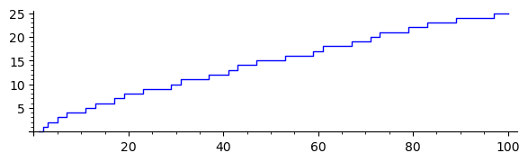

```python
plot(prime_pi, 1,100, aspect_ratio=true)
```

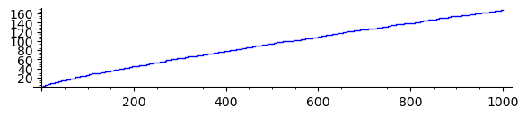

```python
plot(prime_pi, 1,1000, aspect_ratio=true)
```

## Estimação de $\pi(x)$.

- (1798) Adrien-Marie Legendre, usando a tabela de primos de Vega até 400031, aproximou heuristicamente $\pi(x)\approx \displaystyle\frac{x}{log(x)-1.08366}$.
- Gauss conjecturou que $\pi(x)$ cresce à mesma razão que $\frac{x}{log(x)}$ e que $Li(x)=\int_2^x \frac{1}{log(t)} dt$.
- (1850) Chebychev mostrou que, para $x$ suficientemente grande, existem $c_1, c_2 \in \mathbb{R}^+$, com $c_1<1<c_2$, para os quais $$ c_1 \frac{x}{log(x)}<\pi(x)<c_2 \frac{x}{log(x)}.$$ Considerou $c_1 = 0.92129$ e $c_2=1.1056$. Sylvester melhorou com $c_1=0.95695$ e $c_2=1.04423$
- Chebychev: Se $$\displaystyle\frac{\pi(x)}{\frac{x}{log(x)}} $$ é convergente com $x\rightarrow +\infty$ então converge para 1.

## Teorema dos números primos

(Hadamard, Vallée-Poussin)

$$\displaystyle\frac{\pi(x)}{\frac{x}{log(x)}} \displaystyle\rightarrow_{x \rightarrow +\infty} 1.$$

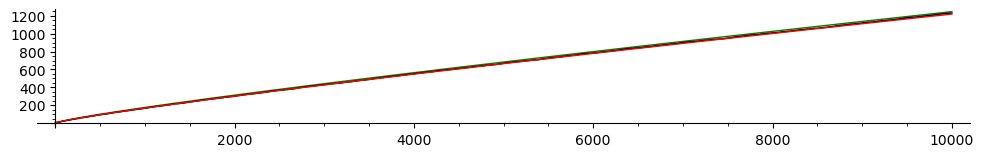

```python
P = plot(Li, 2,10000, rgbcolor='green')
Q = plot(prime_pi, 2,10000, rgbcolor='black')
R = plot(x/(log(x)-1),2,10000,rgbcolor='red')
show(P+Q+R,xmin=0, aspect_ratio=true, figsize=[10,4])
```

Duas funções $f$ e $g$ dizem-se *assimptóticas*, $f\sim g$, se $$\frac{f}{g} \to 1.$$

**Teorema dos Números Primos:**

- $\pi(x) \sim \frac{x}{\log x}$
- $\pi(x) \sim Li(x) = \int_2^x \frac{1}{\log(t)} dt$

### A função $\zeta$ de Riemann

$$\zeta(s) = \sum_{n=1}^\infty \frac{1}{n^s}$$

com $s \in \mathbb{C}$.

```python
zeta(1) #série harmónica
```

```
Infinity
```

```python
zeta(2)
```

```
1/6*pi^2
```

```python
pretty_print(zeta(2))
```

$$\newcommand{\Bold}[1]{\mathbf{#1}}\frac{1}{6} \, \pi^{2}$$

```python
zeta(4)
```

```
1/90*pi^4
```

**Teorema de Euler** , ($s$ natural) $$ \sum_n \frac{1}{n^s} = \prod_{p \in \mathcal{P}} \left( 1-\frac{1}{p^s}\right)^{-1}$$ o que mostra que $\# \mathcal{P} = \aleph_0$.

Para $Re(s)>1$ (na extensão analítica), $$ \zeta(s) = \prod_{p \in \mathcal{P}} \left( 1-\frac{1}{p^s}\right)^{-1}.$$

https://doc.sagemath.org/html/en/reference/plotting/sage/plot/plot.html

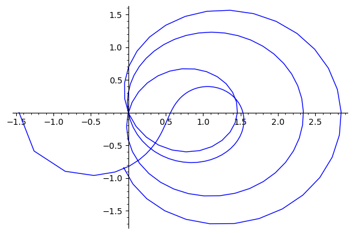

```python
I = CDF.0
show(line([zeta(1/2 + k*I/6) for k in range(180)]))
```

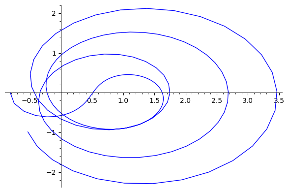

```python
show(line([zeta(1/4 + k*I/6) for k in range(180)]))
```

```python
zeta(-2)
```

```
0
```

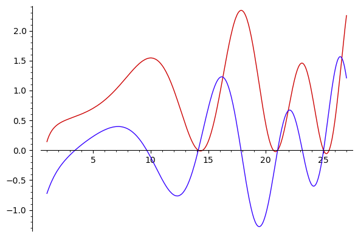

```python
p1 = plot(lambda t: real_part(zeta(0.5+t*I)), 1, 27, rgbcolor=(0.8,0,0))
p2 = plot(lambda t: imag_part(zeta(0.5+t*I)), 1, 27, color=hue(0.7))
p1+p2
```

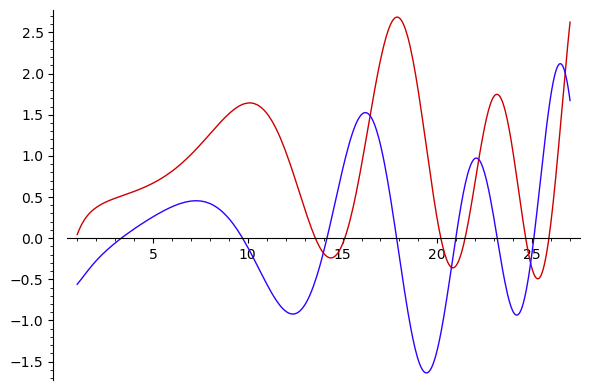

```python
p1 = plot(lambda t: real_part(zeta(0.25+t*I)), 1, 27, rgbcolor=(0.8,0,0))
p2 = plot(lambda t: imag_part(zeta(0.25+t*I)), 1, 27, color=hue(0.7))
p1+p2
```

**Hipótese de Riemann:** *Todos* os zeros não triviais de $\zeta$ estão na linha crítica $$\left\{\frac{1}{2} + bi : b \in \mathbb{R}\right\}.$$

A hipótese de Riemann é uma conjectura, e é um dos problemas do milénio do Clay Institute.

https://demonstrations.wolfram.com/HowTheZerosOfTheZetaFunctionPredictTheDistributionOfPrimes/

$$J(x) = \pi(x)+\frac{1}{2}\pi(x^\frac{1}{2})+\frac{1}{3}\pi(x^\frac{1}{3})+\frac{1}{4}\pi(x^\frac{1}{4})+\cdots, x\in \mathbb{R}$$

$J(x)$ é uma função escada, com saltos:

- 1 se $x$ é primo
- 1/2 se $x$ é um quadrado
- 1/3 se $x$ é um cubo
- etc

$$\pi(x) = \sum_n \mu(n) \frac{J\left(\sqrt[n]{x} \right)}{n}$$

onde $\mu(n)$ é a função de Mobius:

- $1$ se é livre de quadrados e com um número par de factores primos
- $0$ se não é livre de quadrados
- $-1$ se é livre de quadrados e tem um número ímpar de factores primos

$$\pi(x) = J(x) -\frac{1}{2}J\left(x^\frac{1}{2}\right)-\frac{1}{3}J\left(x^\frac{1}{3}\right)-\frac{1}{5}J\left(x^\frac{1}{5}\right)+\frac{1}{6}J\left(x^\frac{1}{6}\right)-\frac{1}{7}J\left(x^\frac{1}{7}\right)+\frac{1}{10}J\left(x^\frac{1}{10}\right)-\cdots$$

$$\pi(100) = J(100) -\frac{1}{2}J\left(100^\frac{1}{2}\right)-\frac{1}{3}J\left(100^\frac{1}{3}\right)-\frac{1}{5}J\left(100^\frac{1}{5}\right)+\frac{1}{6}J\left(100^\frac{1}{6}\right)$$

$$J(x) = Li(x)-\sum_\rho^{+\infty} Li(x^\rho)-\log 2 + \int_x ^{+\infty} \frac{1}{t(t^2-1)\log t}dt $$